# Mental arithmetic in dataviz

Mental arithmetic in dataviz

*A collection of common [dataviz caveats](https://www.data-to-viz.com/caveats.html) by [Data-to-Viz.com](https://www.data-to-viz.com)*

[figure not shown]

# Example

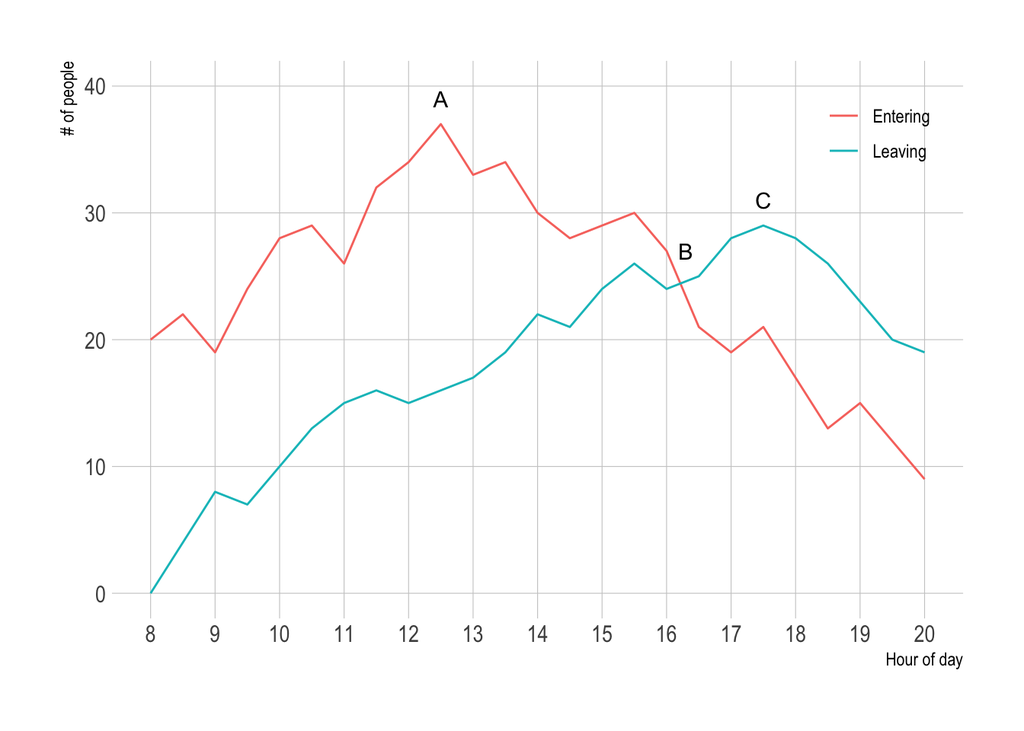

```r
# Libraries
library(tidyverse)
library(hrbrthemes)

# Create data
data <- data.frame(
  x = seq(8,20,0.5),
  Entering = c(20,22,19,24,28,29,26,32,34,37,33,34,30,28,29,30,27,21,19,21,17,13,15,12,9),
  Leaving = c(0,4,8,7,10,13,15,16,15,16,17,19,22,21,24,26,24,25,28,29,28,26,23,20,19)
)

# reformat
data %>%
  gather( key=type, value=value, -1) %>%
  ggplot( aes(x=x, y=value, color=type)) +
    geom_line() +
    ylim(0,40) +
    scale_color_discrete(name="") +
    scale_x_continuous(breaks=seq(8,20,1)) +
    annotate( "text", x=c(12.5, 16.3, 17.5), y=c(39, 27, 31), label=LETTERS[1:3] ) +
    theme_ipsum() +
    theme(
      panel.grid.minor = element_blank(),
      legend.position = c(0.9, 0.9),
    ) +
    ylab("# of people") +
    xlab("Hour of day")
```

Now, what if somebody asks you:

- what is the trend of the total number of people in the shop?
- at what time is the number of people in the shop declining?

# Mental arithmetic

To answer these questions, your audience must think hard and will probably be confused.

- Is it where the marker `A` is, when the number of people entering the shop starts decreasing?
- Or marker `B` where more people are leaving than entering?
- Or `C` where the number of people leaving decreases?

Instead of forcing the reader to make the calculation, it is probably better to represent the number of people in the shop directly:

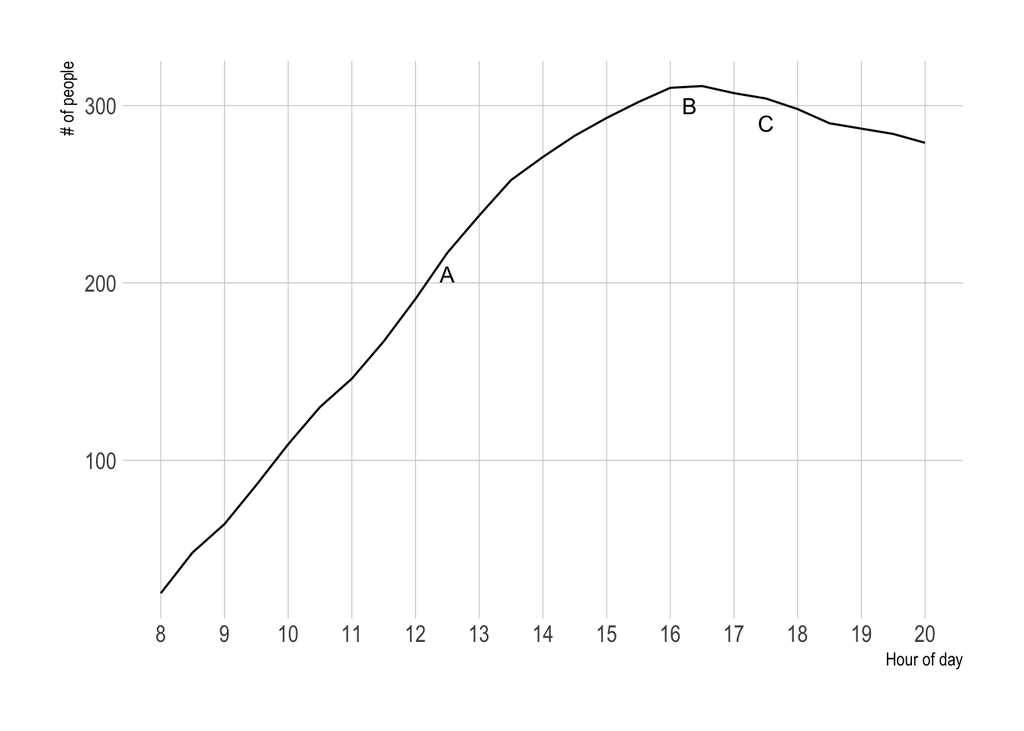

```r
# reformat
data %>%
  mutate(difference=Entering-Leaving + 5) %>%
  mutate(tot = cumsum(difference)) %>%
  ggplot( aes(x=x, y=tot)) +
    geom_line() +
    annotate( "text", x=c(12.5, 16.3, 17.5), y=c(205, 300, 290), label=LETTERS[1:3] ) +
    scale_x_continuous(breaks=seq(8,20,1)) +
    theme_ipsum() +
    theme(
      panel.grid.minor = element_blank()
    ) +
    ylab("# of people") +
    xlab("Hour of day")
```

Of course, if more people leave the shop than enter, the total quantity starts decreasing (marker B). But if you want your audience to focus on your point, do not give them extra work.

# Link with stacking

# Going further

- Inspired from [this talk](http://www.seascapemodels.org/rstats/2018/07/04/dataviz2018_notes.html) by [Chris Brown](https://github.com/cbrown5)

# Comments

Any thoughts on this? Found any mistake? Disagree? Please drop me a word on [twitter](https://twitter.com/R_Graph_Gallery) or in the comment section below:

A work by [Yan Holtz](https://github.com/holtzy/) for data-to-viz.com